# O que você acha que significa ser homem?

Nessa breve análise fizemos uso dos dados obtidos de uma parceria entre **FiveThirtyEight**, **WNYC** e **SurveyMonkey** para uma pesquisa nacional com 1.615 adultos que se identificam como homens. Nessa pesquisa, as entidades os participantes refletirem suas ideias sobre **masculinidade**, cultura do local de trabalho e intimidade, entre outras coisas.

Trata-se de uma pesquisa extensa e rica, portanto, podamos os dados para simplificação.

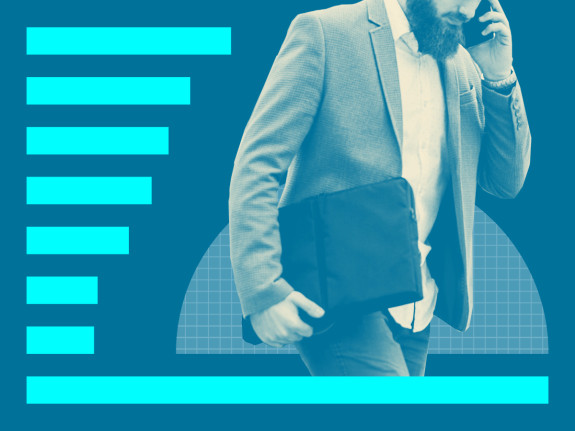

Caso se interesse pelo estudo: https://fivethirtyeight.com/features/what-do-men-think-it-means-to-be-a-man/

## Explicando as variáveis

Transformamos nossas variáveis da seguinte forma:

`masculine` - In general, how masculine or “manly” do you feel?  
Very masculine = 5  
Somewhat masculine = 4  
Not very masculine = 3  
Not at all masculine = 2  
`see_as_masculine` - How important is it to you that others see you as masculine?  
Very important = 5  
Somewhat important = 4  
Not too important = 3  
Not at all important = 2  
`society_pressure_is_bad` - Do you think that society puts pressure on men in a way that is unhealthy or bad for them?  
`first_move` - Do you typically feel as though you’re expected to make the first move in romantic relationships  
`try_pay_date` - How often do you try to be the one who pays when on a date?  
Always  
Often  
Sometimes  
Rarely  
Never  
`age_range` -  
18-34 = 2  
34-64 = 3  
65 or above = 4  
`kids` - Do you have any children?  
`straight` - Are you straight?*  
`white` - Are you white?*  
`state`

ps¹: A pesquisa não pediu a idade exata dos participantes.  
ps²: Na verdade foi perguntado aos participantes sua orientação sexual e raça, mas a fim de pesquisa, transformamos as respostas e adaptamos a pergunta para o formato binário.

## Nosso modelo

```r
data <- data %>% na.omit(data)

md = lm(masculine ~ see_as_masculine +
                      first_move +
                      society_pressure_is_bad +
                      try_pay_date +
                      white +
                      age_range +
                      kids +
                      straight,
        data = data
      )

tidy(md, conf.int = TRUE)
```

```
## # A tibble: 9 x 7
##   term             estimate std.error statistic  p.value conf.low conf.high
##   <chr>               <dbl>     <dbl>     <dbl>    <dbl>    <dbl>     <dbl>
## 1 (Intercept)        3.20      0.146     21.9   2.22e-92   2.92      3.49
## 2 see_as_masculine   0.165     0.0193     8.54  3.13e-17   0.127     0.203
## 3 first_moveYes     -0.113     0.0368    -3.08  2.10e- 3  -0.185    -0.0412
## 4 society_pressur~  -0.0987    0.0346    -2.86  4.35e- 3  -0.167    -0.0309
## 5 try_pay_date       0.100     0.0171     5.86  5.64e- 9   0.0667    0.134
## 6 whiteyes          -0.0414    0.0467    -0.887 3.75e- 1  -0.133     0.0502
## 7 age_range          0.0309    0.0292     1.06  2.90e- 1  -0.0264    0.0882
## 8 kidsyes           -0.0572    0.0382    -1.50  1.34e- 1  -0.132     0.0177
## 9 straightyes        0.163     0.0583     2.79  5.28e- 3   0.0485    0.277
```

```r
glance(md)
```

```
## # A tibble: 1 x 11
##   r.squared adj.r.squared sigma statistic  p.value    df logLik   AIC   BIC
##       <dbl>         <dbl> <dbl>     <dbl>    <dbl> <int>  <dbl> <dbl> <dbl>
## 1     0.103        0.0980 0.647      21.4 5.06e-31     9 -1473. 2966. 3020.
## # ... with 2 more variables: deviance <dbl>, df.residual <int>
```

## Conclusão

Regressão linear múltipla foi utilizada para analisar a associação entre o “O que homens acham que significa ser homem” e as variáveis “O quão importante é que as pessoas o vejam como ‘masculino’” (`see_as_masculine`), “Se você sente que sempre deve dar o primeiro passo nas relações” (`first_move`), “O homem sofre pressão da sociedade”(`society_pressure_is_bad`), “Geralmente pagar ou nao nos encontros” (`try_pay_date`), “Raça”(`white`), “Faixa de idade”(`age_range`), “Ter filhos”(`kids`) e “Orientação sexual” (`straight`), no formato: masculine = 3.20 + (0,165) . see_as_masculine - (0.113) . first_moveYes - (0.0987) . society_pressur + (0.100) . try_pay_date - (0.0414) . whiteyes + (0.0309) age_range - (0.0572) . kidsyes + (0.163) . straightyes que explica **10,3%** da variável de resposta (R² = 0.1028025). Podemos observar, a partir do modelo que a variável `see_as_masculine` é aquela que mais tem influencia, mas ainda assim, baixa.

Mariana Mendes e Matheus Leal

5 de julho de 2019